# DSA4050 Week 11 Assignment: Unsupervised Learning in Computer Vision

**Objective**

This assignment aims to assess your ability to apply unsupervised learning techniques in computer vision. You will work with an image dataset and implement different methods to extract meaningful representations, analyze patterns, and evaluate model performance.

**Github Repository**

Computer Vision: Unsupervised Learning | [https://github.com/Chesia-Anyika/Computer-Vision-Unsupervised-Learning]

## Environment Setup

This assignment was ran in the virtual environment `dsa11`, which was created with the following libraries (saved in requirements.txt)

**Python Version**

- `python 3.8`

**Essential libraries**

- `numpy`: For numerical computations.
- `scipy`: For scientific computing
- `matplotlib` `seaborn`: For visualizations.
- `scikit-learn` `scikit-image`: For clustering (K-Means, DBSCAN), PCA, and evaluation metrics (Silhouette Score).
- `opencv-python`: For image processing tasks (e.g., grayscale conversion, data augmentation).
- `pillow`: For handling image file formats.
- `torch`: For implementing SimCLR and training neural networks.
- `torchvision`: For working with pretrained models and datasets.
- `tqdm`: For progress bars during training.
- `tensorboard`: for SimCLR implementation

**GPU Support**

- `torch` `torchvision` `torchaudio` from [https://download.pytorch.org/whl/cu118]

To verify the GPU availability, run the following:

```python
import torch
print("CUDA Available:", torch.cuda.is_available())
print("GPU Device:", torch.cuda.get_device_name(0))
```

```
CUDA Available: True
GPU Device: NVIDIA GeForce RTX 3050 Laptop GPU
```

**Directory Structure**

```
DSA4050_w11_Assignment/
├── data/                      # Dataset folder
│   ├── Road Cracks/     # Road Crack dataset
├── notebooks/                 # Jupyter notebook
│   ├── DSA4050_W11_Assignment.ipynb
├── requirements.txt           # List of dependencies
├── Week 11 Assignment.pdf     # Assignment Question
```

## Task 1: Image Data Preprocessing (10 marks)

1. Use the Road Crackimage dataset
2. Perform necessary data preprocessing:
- Convert images to grayscale (if required).
- Normalize pixel values.
- Apply data augmentation techniques (e.g., flipping, rotation).

**Deliverables:**

- Code implementation
- Short explanation of preprocessing steps

### Step 1: Import Required Libraries

We need these libraries for image processing, data augmentation, and visualization.

```python
import os
import cv2
import numpy as np
import matplotlib.pyplot as plt
from torchvision import transforms
from torch.utils.data import Dataset, DataLoader
```

### Step 2: Load the Road Crack Image Dataset

The dataset is stored in the following directory: `C:\Users\anyik\OneDrive\Documents\2.Course_Files\DSA4050\DSA4050_w11_Assignment\data\Road cracks`. Each image is either a crack or non-crack image.

```python
# Define the path to the dataset
dataset_path = r"C:\Users\anyik\OneDrive\Documents\2.Course_Files\DSA4050\DSA4050_w11_Assignment\data\Road cracks"

# List all image files in the dataset folder
image_files = [os.path.join(dataset_path, fname) for fname in os.listdir(dataset_path) if fname.endswith(('.jpg', '.png'))]
print(f"Total images found: {len(image_files)}")
```

```
Total images found: 125
```

### Step 3: Convert Images to Grayscale

Converting images to grayscale in computer vision reduces computational complexity and removes color redundancy, allowing algorithms to focus on essential structural and intensity features.

Since the images are in color, we will convert them to grayscale using `OpenCV.`

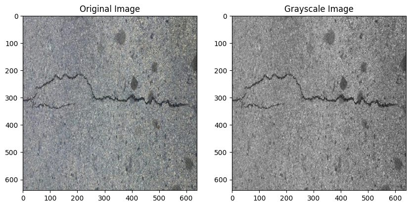

```python
def load_and_convert_to_grayscale(image_path):
    # Load the image using OpenCV
    image = cv2.imread(image_path)
    # Convert to grayscale
    gray_image = cv2.cvtColor(image, cv2.COLOR_BGR2GRAY)
    return gray_image

# Test the function on a sample image
sample_image_path = image_files[0]  # Take the first image for demonstration
gray_image = load_and_convert_to_grayscale(sample_image_path)

# Display the original and grayscale image
plt.figure(figsize=(10, 5))
plt.subplot(1, 2, 1)
plt.title("Original Image")
plt.imshow(cv2.cvtColor(cv2.imread(sample_image_path), cv2.COLOR_BGR2RGB))

plt.subplot(1, 2, 2)
plt.title("Grayscale Image")
plt.imshow(gray_image, cmap='gray')
plt.show()
```

### Step 4: Normalize Pixel Values

Normalizing pixels ensures that image data is on a consistent scale, which helps improve the performance and convergence speed of machine learning models. Pixel values are typically in the range $[0, 255]$, and normalization transforms them to ranges like $[0, 1]$, $[-1, 1]$, or with **zero mean and unit variance**. This prevents features with larger values from dominating and helps models learn more effectively.

We will normalize the pixel values to the range $[0, 1]$ by dividing each pixel by 255. We can then visualise the output, seeing how the x-axis scale changes to the appropriate range

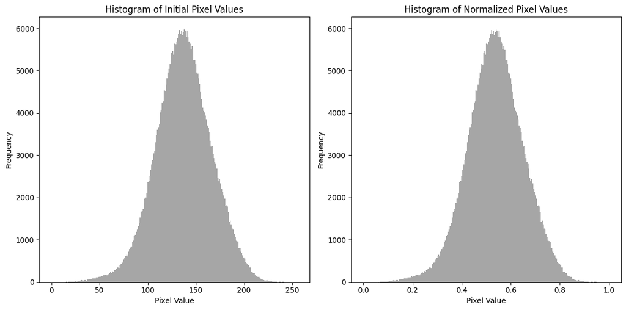

```python
import matplotlib.pyplot as plt

def normalize_image(image):
    # Normalize pixel values to [0, 1]
    normalized_image = image / 255.0
    return normalized_image

# Normalize the grayscale image
normalized_image = normalize_image(gray_image)

# Display histograms of the initial and normalized pixel values
plt.figure(figsize=(12, 6))

# Histogram of the initial pixel values
plt.subplot(1, 2, 1)
plt.hist(gray_image.ravel(), bins=256, range=(0, 255), color='gray', alpha=0.7)
plt.title("Histogram of Initial Pixel Values")
plt.xlabel("Pixel Value")
plt.ylabel("Frequency")

# Histogram of the normalized pixel values
plt.subplot(1, 2, 2)
plt.hist(normalized_image.ravel(), bins=256, range=(0, 1), color='gray', alpha=0.7)
plt.title("Histogram of Normalized Pixel Values")
plt.xlabel("Pixel Value")
plt.ylabel("Frequency")

plt.tight_layout()
plt.show()
```

### Step 5: Apply Data Augmentation Techniques

Data augmentation increases the diversity and size of the training dataset by applying transformations like rotation, flipping, cropping, or brightness adjustment to existing images. This helps prevent overfitting, improves model generalization, and boosts performance, especially when the original dataset is limited.. We will use `torchvision.transforms` to apply data augmentation techniques like flipping and rotation.

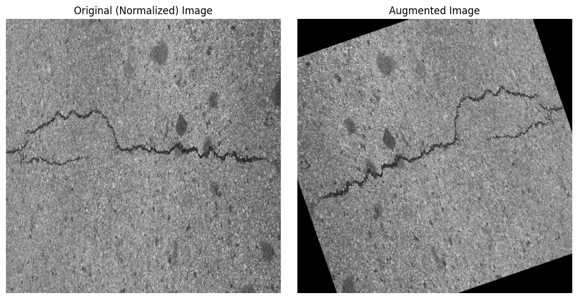

```python
# Define data augmentation transformations
data_augmentation = transforms.Compose([
    transforms.ToPILImage(),  # Convert NumPy array to PIL image
    transforms.RandomHorizontalFlip(p=0.5),  # Random horizontal flip
    transforms.RandomRotation(degrees=30),   # Random rotation up to 30 degrees
    transforms.ToTensor()                    # Convert back to tensor
])

# Apply augmentation to the normalized image
augmented_image = data_augmentation(normalized_image)

# Convert augmented image back to NumPy for visualization
augmented_image_np = augmented_image.numpy().transpose(1, 2, 0)  # Transpose to (H, W, C)

# Display the original and augmented images side by side
plt.figure(figsize=(10, 5))

# Original (normalized) image
plt.subplot(1, 2, 1)
plt.title("Original (Normalized) Image")
plt.imshow(normalized_image, cmap='gray')
plt.axis('off')  # Turn off axis labels

# Augmented image
plt.subplot(1, 2, 2)
plt.title("Augmented Image")
plt.imshow(augmented_image_np, cmap='gray')
plt.axis('off')  # Turn off axis labels

plt.tight_layout()
plt.show()
```

### Step 6: Combine All Preprocessing Steps

I then combiened all these steps into a single function for batch processing, and applied them to the whole road cracks dataset. I saved the preprocessed images to `C:\Users\anyik\OneDrive\Documents\2.Course_Files\DSA4050\DSA4050_w11_Assignment\data\preprocessed road cracks`.

```python
import os
from torchvision.utils import save_image

# Define the directory to save preprocessed images
output_dir = r"C:\Users\anyik\OneDrive\Documents\2.Course_Files\DSA4050\DSA4050_w11_Assignment\data\preprocessed road cracks"
os.makedirs(output_dir, exist_ok=True)  # Create the directory if it doesn't exist

def preprocess_image(image_path, output_dir):
    # Step 1: Load and convert to grayscale
    gray_image = load_and_convert_to_grayscale(image_path)

    # Step 2: Normalize pixel values
    normalized_image = normalize_image(gray_image)

    # Step 3: Apply data augmentation
    augmented_image = data_augmentation(normalized_image)

    # Step 4: Save the augmented image to the output directory
    # Extract the base filename (e.g., "image.jpg") from the full path
    base_filename = os.path.basename(image_path)
    # Construct the output file path
    output_path = os.path.join(output_dir, f"augmented_{base_filename}")
    # Save the augmented image using torchvision's save_image function
    save_image(augmented_image, output_path)

    return augmented_image

# Example usage: Preprocess all images in the dataset
preprocessed_images = []
for img_path in image_files:
    preprocessed_img = preprocess_image(img_path, output_dir)
    preprocessed_images.append(preprocessed_img)

print(f"Total preprocessed images: {len(preprocessed_images)}")
print(f"Preprocessed images saved to: {output_dir}")
```

```
Total preprocessed images: 125
Preprocessed images saved to: C:\Users\anyik\OneDrive\Documents\2.Course_Files\DSA4050\DSA4050_w11_Assignment\data\preprocessed road cracks
```

## Task 2: Clustering for Image Categorization (20 marks)

1. Extract features from images using Histogram of Oriented Gradients (HOG), ORB, or deep features from a pretrained CNN.
2. Apply K-Means and DBSCAN clustering to group similar images.
3. Use the Silhouette Score to evaluate clustering quality.

**Deliverables:**

- Code for feature extraction and clustering
- Visualization of clusters (e.g., sample images from each cluster)
- Evaluation and interpretation of results

### Step 1: Import Required Libraries

We need these libraries for feature extraction, clustering, and visualization.

```python
import os
import numpy as np
import cv2
from skimage.feature import hog
from sklearn.cluster import KMeans, DBSCAN
from sklearn.metrics import silhouette_score
from sklearn.manifold import TSNE
from torchvision import models, transforms
import torch
import torch.nn as nn
import matplotlib.pyplot as plt
from PIL import Image
```

### Step 2: Load the Dataset

I am using my preprocessed dataset from *Task 1*. It is already loaded into the system, but can be located int he directory `C:\Users\anyik\OneDrive\Documents\2.Course_Files\DSA4050\DSA4050_w11_Assignment\data\preprocessed road cracks`.

```python
# Define the path to the dataset
dataset_path = r"C:\Users\anyik\OneDrive\Documents\2.Course_Files\DSA4050\DSA4050_w11_Assignment\data\preprocessed road cracks"

# List all image files in the dataset folder
image_files = [os.path.join(dataset_path, fname) for fname in os.listdir(dataset_path) if fname.endswith(('.jpg', '.png'))]
print(f"Total images found: {len(image_files)}")
```

```
Total images found: 125
```

### Step 3: Feature Extraction Using HOG

HOG (Histogram of Oriented Gradients) features are a type of feature descriptor used in computer vision that capture the distribution of gradient directions (edge orientations) within localized regions of an image. They are computed by dividing the image into small cells, calculating gradient directions in each cell, and forming histograms of these directions.

**Significance:** HOG features are effective for object detection tasks, especially in capturing the shape and structure of objects like humans or vehicles, while being invariant to changes in lighting and small deformations. They help models focus on the shape and contour information crucial for recognizing objects.

Below I loaded each image in grayscale, resized it to 128×128, extracted its HOG features using defined cell and block sizes, and stored all the feature vectors in a NumPy array. Furthermore, I visualised each image as its original, and its HOG features.

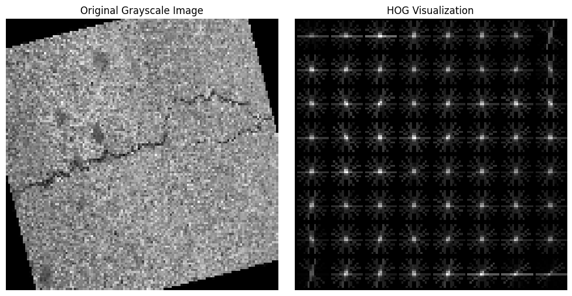

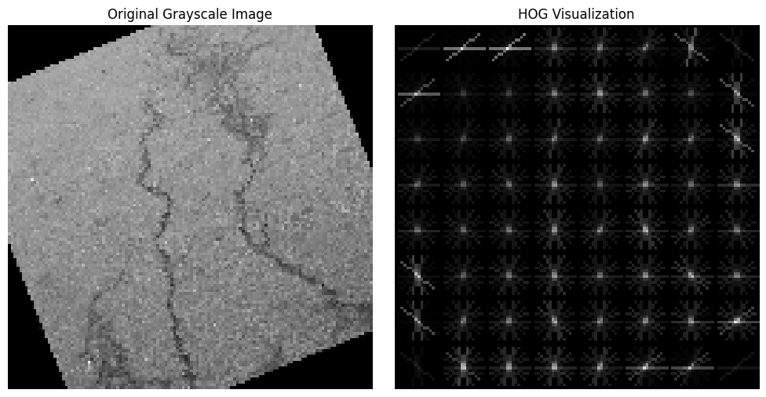

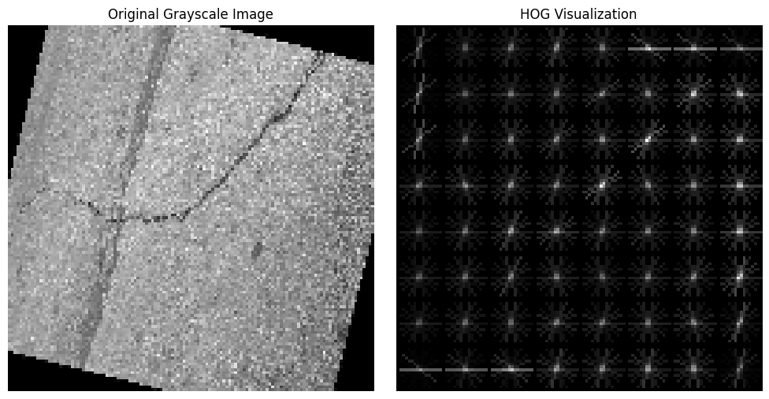

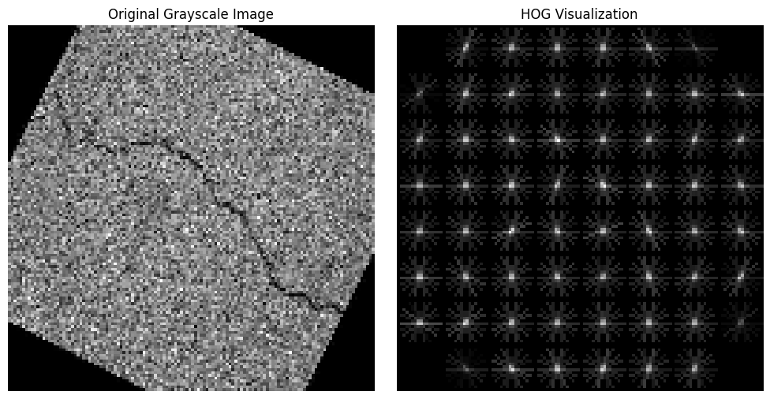

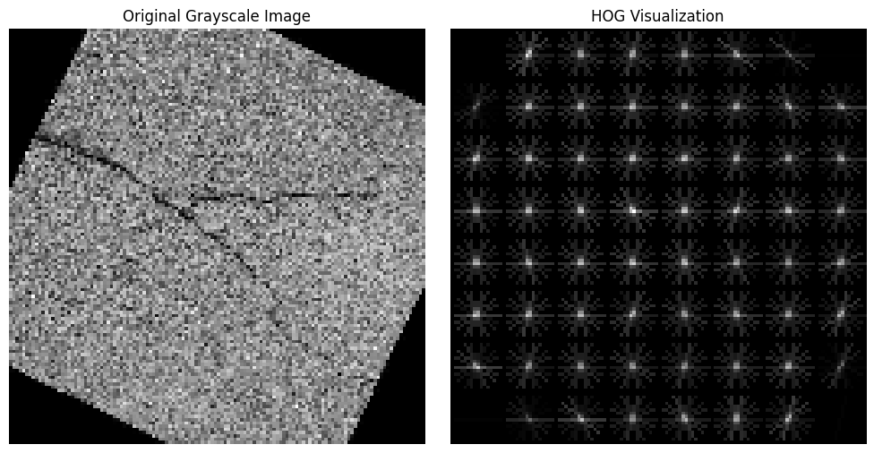

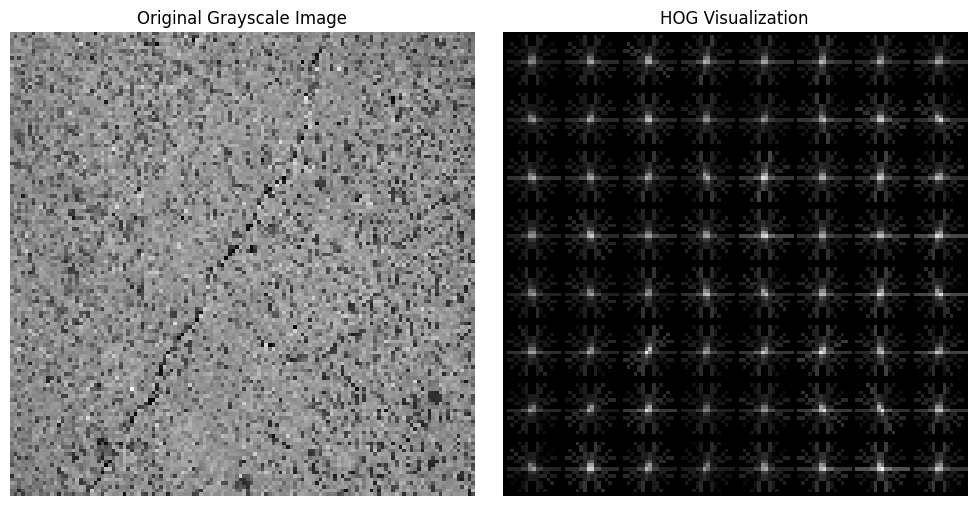

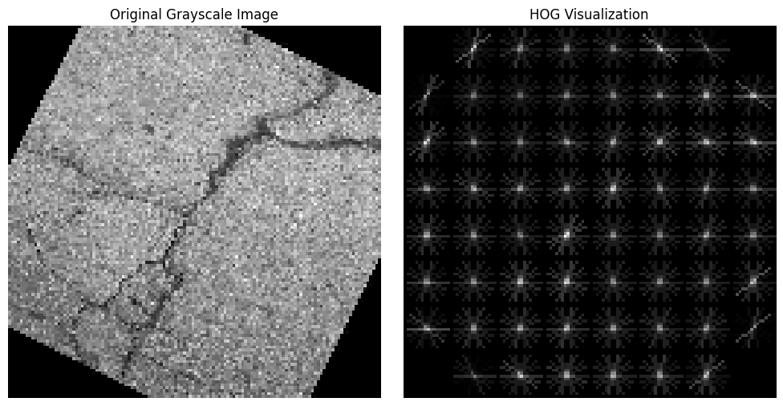

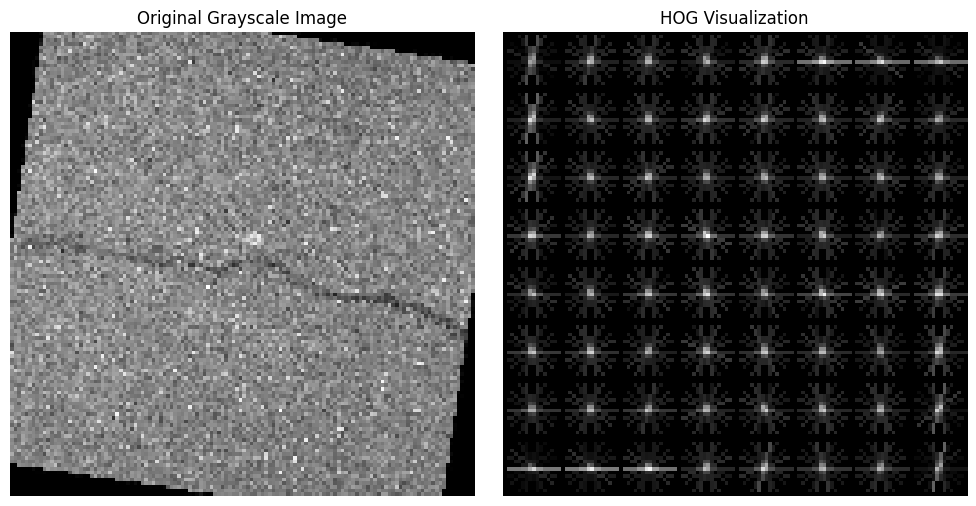

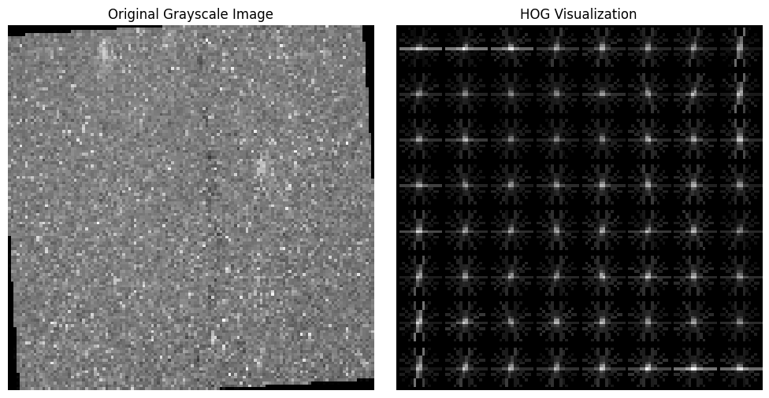

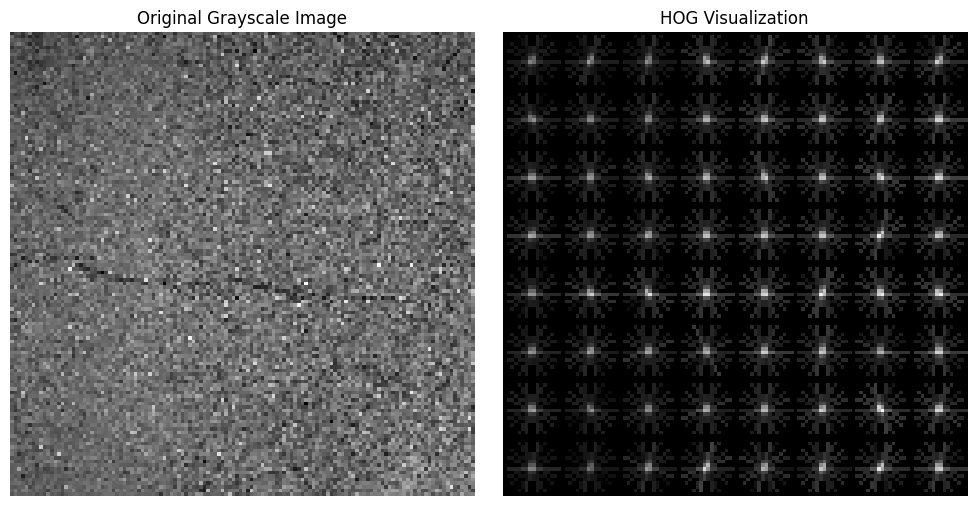

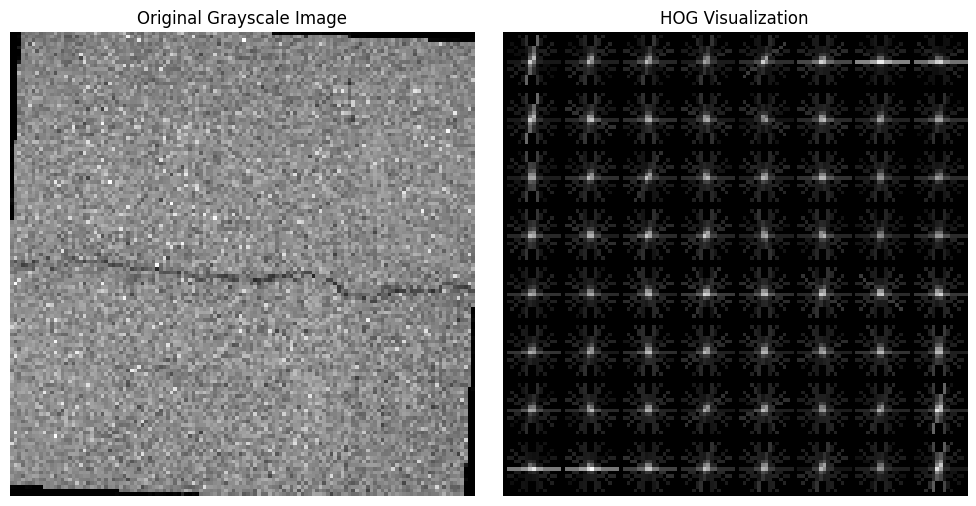

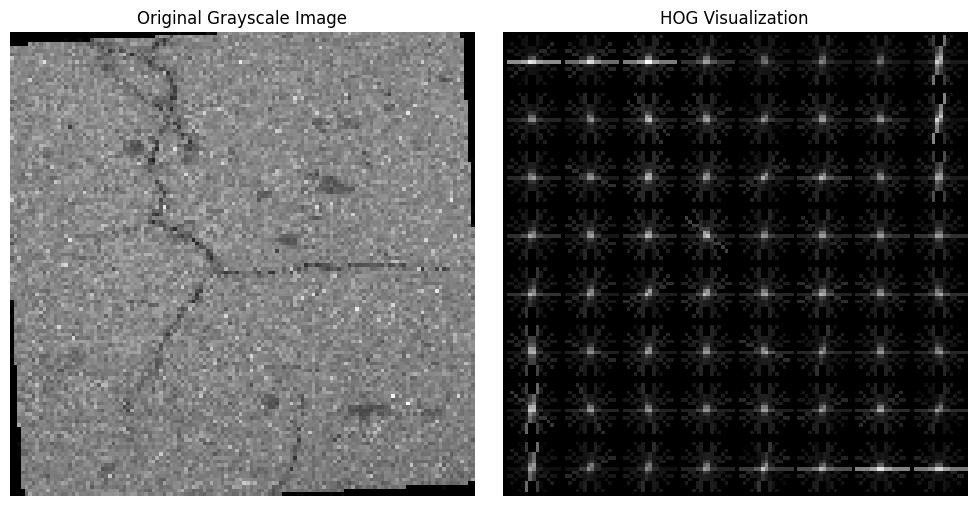

[113 more figures not shown]

```
HOG features shape: (125, 1764)
```

```python
def extract_and_visualize_hog(image_path):
    # Load the image in grayscale
    image = cv2.imread(image_path, cv2.IMREAD_GRAYSCALE)
    # Resize the image to a fixed size (e.g., 128x128)
    image = cv2.resize(image, (128, 128))

    # Compute HOG features and visualize the gradients
    features, hog_image = hog(
        image,
        pixels_per_cell=(16, 16),
        cells_per_block=(2, 2),
        visualize=True,
        feature_vector=True
    )

    # Display the original image and the HOG visualization
    plt.figure(figsize=(10, 5))

    # Original Grayscale Image
    plt.subplot(1, 2, 1)
    plt.title("Original Grayscale Image")
    plt.imshow(image, cmap='gray')
    plt.axis('off')  # Turn off axis labels

    # HOG Visualization
    plt.subplot(1, 2, 2)
    plt.title("HOG Visualization")
    plt.imshow(hog_image, cmap='gray')
    plt.axis('off')  # Turn off axis labels

    plt.tight_layout()
    plt.show()

    return features

# Extract HOG features for all images
hog_features = np.array([extract_and_visualize_hog(img_path) for img_path in image_files])
print(f"HOG features shape: {hog_features.shape}")
```

### Step 4: Feature Extraction Using Pretrained CNN

Alternatively, extract deep features using a pretrained CNN (e.g., ResNet).

Convolutional Neural Networks (CNNs) are powerful architectures designed to automatically learn spatial hierarchies of features from images, making them ideal for deep feature extraction. Instead of manually designing features (like HOG or SIFT), CNNs learn complex patterns such as edges, textures, and object parts directly from the data through multiple convolutional layers.

I’ve chosen to use a pretrained model like ResNet because it has already learned rich and generalizable features from a large dataset (e.g., ImageNet), allowing me to leverage this knowledge for your dataset without training from scratch. This not only saves time and computational resources but also improves performance, especially if the dataset is small or lacks diversity.

After applying feature extraction i visualised the features using a scatterplot and heat maps.

```
CNN features shape: (125, 512)
```

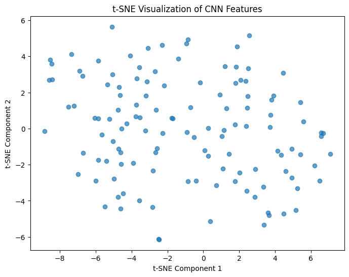

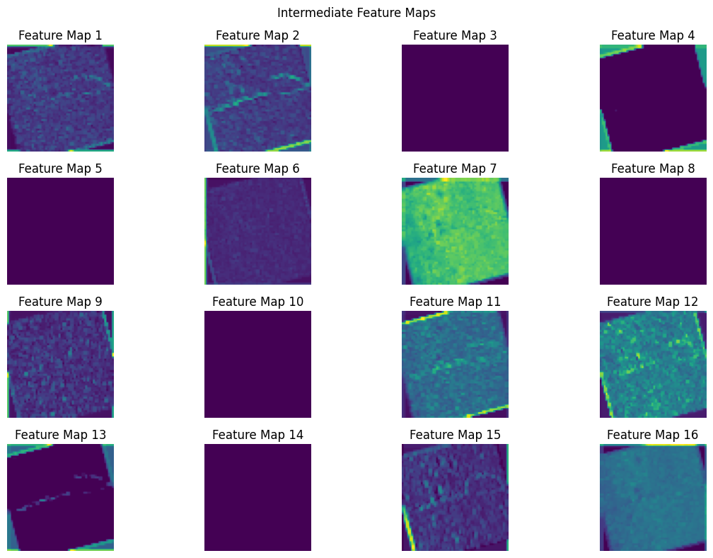

```python
# Load a pretrained ResNet model
model = models.resnet18(pretrained=True)
model = nn.Sequential(*list(model.children())[:-1])  # Remove the final classification layer
model.eval()

# Define preprocessing transformations
preprocess = transforms.Compose([
    transforms.Resize((224, 224)),
    transforms.ToTensor(),
    transforms.Normalize(mean=[0.485, 0.456, 0.406], std=[0.229, 0.224, 0.225])
])

def extract_cnn_features(image_path):
    # Load and preprocess the image
    image = Image.open(image_path).convert('RGB')
    image_tensor = preprocess(image).unsqueeze(0)  # Add batch dimension
    # Extract features using the pretrained model
    with torch.no_grad():
        features = model(image_tensor)
    return features.numpy().flatten()

# Extract CNN features for all images
cnn_features = np.array([extract_cnn_features(img_path) for img_path in image_files])
print(f"CNN features shape: {cnn_features.shape}")

# 1. Visualize Reduced-Dimensional Features using t-SNE
tsne = TSNE(n_components=2, random_state=42)
reduced_features = tsne.fit_transform(cnn_features)

plt.figure(figsize=(8, 6))
plt.scatter(reduced_features[:, 0], reduced_features[:, 1], alpha=0.7)
plt.title("t-SNE Visualization of CNN Features")
plt.xlabel("t-SNE Component 1")
plt.ylabel("t-SNE Component 2")
plt.show()

# 2. Visualize Intermediate Feature Maps
def visualize_feature_maps(image_path):
    # Load and preprocess the image
    image = Image.open(image_path).convert('RGB')
    image_tensor = preprocess(image).unsqueeze(0)  # Add batch dimension

    # Select a layer to visualize (e.g., layer 4 of ResNet)
    layer = model[0:4]  # First few layers of ResNet
    with torch.no_grad():
        feature_maps = layer(image_tensor)

    # Convert feature maps to NumPy array
    feature_maps = feature_maps.squeeze(0).numpy()

    # Plot the first 16 feature maps
    num_feature_maps = min(feature_maps.shape[0], 16)
    plt.figure(figsize=(12, 8))
    for i in range(num_feature_maps):
        plt.subplot(4, 4, i + 1)
        plt.imshow(feature_maps[i], cmap='viridis')
        plt.axis('off')
        plt.title(f"Feature Map {i + 1}")
    plt.suptitle("Intermediate Feature Maps")
    plt.tight_layout()
    plt.show()

# Visualize feature maps for the first image in the dataset
visualize_feature_maps(image_files[0])
```

### Step 5: Apply K-Means Clustering

K-Means is an unsupervised learning algorithm that groups similar data points into clusters by minimizing the distance to the centroid of each cluster, and its significance in computer vision lies in its ability to identify patterns or objects within images based on their feature similarities.

The elbow plot helps determine the optimal number of clusters by plotting the inertia (within-cluster sum of squares) against different values of K, with the "elbow" indicating the point where adding more clusters no longer significantly improves the clustering.

Below, I determined the kmeans score then plotted an elbow plot:

```python
# Define the number of clusters
n_clusters = 2  # Assuming two categories: crack and non-crack

# Apply K-Means clustering
kmeans = KMeans(n_clusters=n_clusters, random_state=42)
kmeans_labels = kmeans.fit_predict(hog_features)  # Use HOG features (or cnn_features)

# Evaluate clustering quality using Silhouette Score
silhouette_avg = silhouette_score(hog_features, kmeans_labels)
print(f"K-Means Silhouette Score: {silhouette_avg:.2f}")
```

```
K-Means Silhouette Score: 0.09
```

**Interpretation**

*Silhouette Score of 0.09* :

The Silhouette Score measures how well each data point fits into its assigned cluster compared to other clusters.

A score close to 1 indicates that the clusters are well-separated, while a score close to 0 suggests overlapping clusters or poor separation.

A score of 0.09 is very low, indicating that:

- The clusters are not well-separated.
- There may be significant overlap between the clusters.
- The clustering structure might not be meaningful for your data.

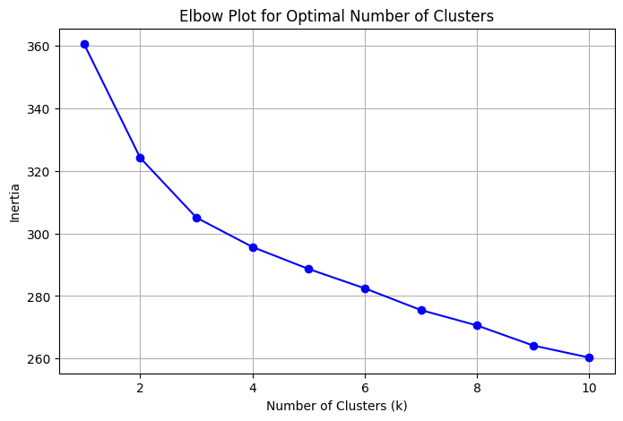

```python
# Define a range of k values to test
k_values = range(1, 11)
inertia_values = []

# Calculate inertia for each k
for k in k_values:
    kmeans = KMeans(n_clusters=k, random_state=42)
    kmeans.fit(hog_features)  # Use HOG features (or cnn_features)
    inertia_values.append(kmeans.inertia_)

# Plot the elbow plot
plt.figure(figsize=(8, 5))
plt.plot(k_values, inertia_values, marker='o', linestyle='-', color='b')
plt.title("Elbow Plot for Optimal Number of Clusters")
plt.xlabel("Number of Clusters (k)")
plt.ylabel("Inertia")
plt.grid(True)
plt.show()
```

**Interpretation**

*Elbow Plot Suggests 2 Clusters* :

The elbow plot identifies the "optimal" number of clusters based on the reduction in inertia (sum of squared distances to cluster centers).

If the elbow plot shows a clear bend at `k=2`, it suggests that adding more clusters beyond 2 does not significantly reduce inertia.

However, the elbow plot does not guarantee meaningful clusters —it only helps identify the point where diminishing returns occur in terms of inertia reduction.

**Visualisation of Clusters**

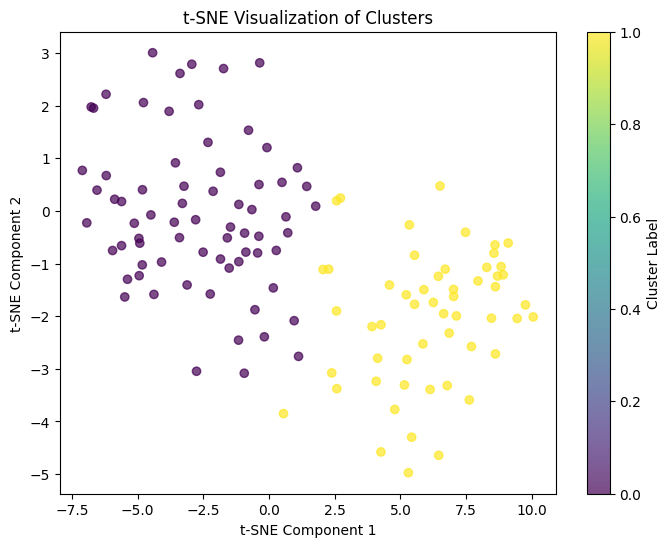

```python
from sklearn.manifold import TSNE

# Reduce dimensions to 2D
tsne = TSNE(n_components=2, random_state=42)
reduced_features = tsne.fit_transform(hog_features)

# Plot clusters
plt.figure(figsize=(8, 6))
plt.scatter(reduced_features[:, 0], reduced_features[:, 1], c=kmeans_labels, cmap='viridis', alpha=0.7)
plt.title("t-SNE Visualization of Clusters")
plt.xlabel("t-SNE Component 1")
plt.ylabel("t-SNE Component 2")
plt.colorbar(label="Cluster Label")
plt.show()
```

### Step 6: Apply DBSCAN Clustering

DBSCAN (Density-Based Spatial Clustering of Applications with Noise) is a clustering algorithm that groups points based on their density, identifying core points surrounded by neighbors, and its significance in computer vision lies in its ability to detect clusters of arbitrary shape and handle noise (outliers) without needing a predefined number of clusters. I applied this as follows:

```python
# Apply DBSCAN clustering
dbscan = DBSCAN(eps=0.5, min_samples=5)
dbscan_labels = dbscan.fit_predict(hog_features)  # Use HOG features (or cnn_features)

# Evaluate clustering quality using Silhouette Score
if len(set(dbscan_labels)) > 1:  # Silhouette Score requires at least 2 clusters
    silhouette_avg = silhouette_score(hog_features, dbscan_labels)
    print(f"DBSCAN Silhouette Score: {silhouette_avg:.2f}")
else:
    print("DBSCAN did not find more than one cluster.")
```

```
DBSCAN did not find more than one cluster.
```

**Interpretation**

When DBSCAN identifies only one cluster, it means that all the data points are considered part of a single dense region, and there are no points classified as outliers or noise. This typically indicates that the points are closely packed together, forming a cohesive group with no significant gaps or sparsely populated areas.This si similar to the kmeans clustering analysis that showed lack of significant space between clusters of images.

### Overall Visualisation of Clusters

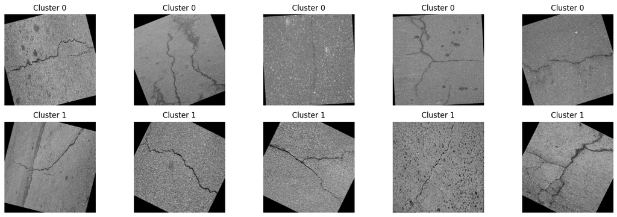

```python
def visualize_clusters(image_files, labels, n_clusters):
    plt.figure(figsize=(15, 5))
    for cluster_id in range(n_clusters):
        cluster_images = [img for img, label in zip(image_files, labels) if label == cluster_id]
        for i, img_path in enumerate(cluster_images[:5]):  # Show up to 5 images per cluster
            plt.subplot(n_clusters, 5, cluster_id * 5 + i + 1)
            plt.imshow(cv2.cvtColor(cv2.imread(img_path), cv2.COLOR_BGR2RGB))
            plt.title(f"Cluster {cluster_id}")
            plt.axis('off')
    plt.tight_layout()
    plt.show()

# Visualize K-Means clusters
visualize_clusters(image_files, kmeans_labels, n_clusters)

# Visualize DBSCAN clusters (if applicable)
if len(set(dbscan_labels)) > 1:
    visualize_clusters(image_files, dbscan_labels, len(set(dbscan_labels)))
```

**Interpretation**

The two kmeans clusters seem to differ in the **augmentation direction of the images** rather than the actual characteristics of the images themselves. Cluster 0 images seem to lean towards the left, and cluster 1 images towards the right. DBscan clusters are not visualised as the algorithm only identified one cluster.

**Overall interpretation**

- There are two identified clusters of images, **Cluster 0** and **Cluster 1**.
- The difference seems to be identified as the augmentation direction of the images.
- The images are quite similar in terms of their features, and the clustering algorithms indicated overlapping characteristics between clusters.

### Save Clusters as Image Categories

I saved the Kmeans clusters, `Cluster 0` & `Cluster 1` as the image categories in the following directory: `C:\Users\anyik\OneDrive\Documents\2.Course_Files\DSA4050\DSA4050_w11_Assignment\data\kmeans road cracks`

These will be used for training a SimCLR model in Task 4.

```python
import os
import shutil

#define save function
def save_clusters_to_directories(image_files, labels, output_dir):
    """
    Save images into separate directories based on their cluster labels.

    Args:
        image_files (list): List of image file paths.
        labels (list): Cluster labels for each image.
        output_dir (str): Directory where clusters will be saved.
    """
    # Create the output directory if it doesn't exist
    os.makedirs(output_dir, exist_ok=True)

    # Iterate over all images and their labels
    for img_path, label in zip(image_files, labels):
        # Create a subdirectory for the cluster if it doesn't exist
        cluster_dir = os.path.join(output_dir, f"cluster_{label}")
        os.makedirs(cluster_dir, exist_ok=True)

        # Copy the image to the appropriate cluster directory
        img_name = os.path.basename(img_path)
        shutil.copy(img_path, os.path.join(cluster_dir, img_name))
```

```python
# Define the output directory for K-Means clusters
kmeans_output_dir = r"C:\Users\anyik\OneDrive\Documents\2.Course_Files\DSA4050\DSA4050_w11_Assignment\data\kmeans road cracks"

# Save K-Means clusters to directories
save_clusters_to_directories(image_files, kmeans_labels, kmeans_output_dir)

print(f"K-Means clusters saved to: {kmeans_output_dir}")
```

```
K-Means clusters saved to: C:\Users\anyik\OneDrive\Documents\2.Course_Files\DSA4050\DSA4050_w11_Assignment\data\kmeans road cracks
```

## Task 3: Dimensionality Reduction and Visualization (20 marks)

1. Apply Principal Component Analysis (PCA) and t-SNE to reduce image featuredimensions.
2. Visualize the results in 2D plots.

**Deliverables:**

- Code for PCA and t-SNE
- Scatter plots with labeled clusters
- Discussion on differences in PCA vs. t-SNE results

### Step 1: Import Required Libraries

We need libraries for dimensionality reduction, visualization, and data handling.

```python
import numpy as np
import matplotlib.pyplot as plt
from sklearn.decomposition import PCA
from sklearn.manifold import TSNE
from sklearn.preprocessing import StandardScaler
```

### Step 2: Load Preprocessed Features

I already have preprocessed features (HOG and CNN features) from Task 2. I chose to use the CNN features saved under the variable `cnn_features`.

```python
# Example: Load preprocessed features (replace with your actual features)
features = cnn_features

# Standardize the features (important for PCA and t-SNE)
scaler = StandardScaler()
standardized_features = scaler.fit_transform(features)

print(f"Feature shape after standardization: {standardized_features.shape}")
```

```
Feature shape after standardization: (125, 512)
```

### Step 3: Apply PCA

Principal Component Analysis (PCA) is a dimensionality reduction technique that transforms high-dimensional data into a lower-dimensional space by identifying the directions (principal components) that capture the most variance.

PCA helps reduce computational complexity, removes noise, and enhances the performance of models by compressing image data while preserving essential features like structure and texture.

I applied PCA as follows:

```python
# Define the number of components (reduce to 2D for visualization)
pca = PCA(n_components=2, random_state=42)
pca_result = pca.fit_transform(standardized_features)

print(f"Explained variance ratio: {pca.explained_variance_ratio_}")
```

```
Explained variance ratio: [0.12028591 0.08430492]
```

### Step 4: Apply t-SNE

t-SNE (t-Distributed Stochastic Neighbor Embedding) is a nonlinear dimensionality reduction technique that maps high-dimensional data into 2 or 3 dimensions while preserving local structure and similarities.

t-SNE is widely used for visualizing complex image feature representations, such as embeddings from CNNs, making it easier to understand patterns, clusters, or class separations in visual data.

I applied t-SNE as follows:

```python
# Apply t-SNE for dimensionality reduction
tsne = TSNE(n_components=2, perplexity=30, random_state=42, n_iter=1000)
tsne_result = tsne.fit_transform(standardized_features)
```

### Step 5: Compare PCA and t-SNE Results

Generally, PCA and T-SNE differ int he following ways:

| Aspect | **PCA** | **t-SNE** |
| --- | --- | --- |
| **Type** | Linear dimensionality reduction | Nonlinear dimensionality reduction |
| **Goal** | Preserve global variance structure | Preserve local structure (neighborhoods) |
| **Interpretability** | Easy to interpret (principal components are linear) | Less interpretable due to nonlinear mapping |
| **Speed** | Fast, scalable to large datasets | Slower, especially on large datasets |
| **Output Dimensions** | Can reduce to any number of components | Typically used for 2D or 3D visualization |
| **Use Case in CV** | Feature compression, noise reduction, preprocessing | Visualizing feature clusters or embeddings from CNNs |
| **Preserves Distance?** | Preserves overall Euclidean distances | Preserves relative distances in local clusters |

**Summary:**

PCA is better for general-purpose dimensionality reduction and preprocessing, while **t-SNE is ideal for visualizing complex patterns** or clusters in high-dimensional visual data.

**Practical Comparison**

I visualised both the PCA and t-SNE features in scatterplots to visually compare their performance ont he same CNN features:

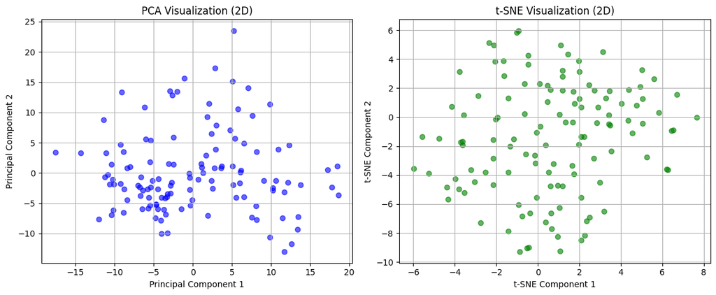

```python
# Combined scatter plot for comparison
plt.figure(figsize=(12, 5))

# PCA subplot
plt.subplot(1, 2, 1)
plt.scatter(pca_result[:, 0], pca_result[:, 1], c='blue', alpha=0.6)
plt.title("PCA Visualization (2D)")
plt.xlabel("Principal Component 1")
plt.ylabel("Principal Component 2")
plt.grid(True)

# t-SNE subplot
plt.subplot(1, 2, 2)
plt.scatter(tsne_result[:, 0], tsne_result[:, 1], c='green', alpha=0.6)
plt.title("t-SNE Visualization (2D)")
plt.xlabel("t-SNE Component 1")
plt.ylabel("t-SNE Component 2")
plt.grid(True)

plt.tight_layout()
plt.show()
```

**Interpretation**

*PCA Visualization* :

- The PCA plot shows a relatively uniform distribution of points.
- Clusters appear less distinct, and there is no clear separation between groups.
- This suggests that PCA might not be capturing the underlying structure effectively for this dataset.

**Key Observations**

**t-SNE :** t-SNE excels at visualizing local patterns and clusters, making it more suitable for exploratory analysis and understanding the dataset's fine-grained structure.

## Task 4: Contrastive Learning for Representation Learning (30 marks)

1. Implement SimCLR or another contrastive learning approach to learn visual representations.
2. Train the model using contrastive loss and visualize the learned representations using tSNE.
3. Evaluate the learned representations by training a simple classifier on top of them.

**Deliverables:**

- Code for SimCLR implementation
- t-SNE visualization of learned representations
- Comparison of classifier accuracy with vs. without contrastive learning

### Step 1: Import Required Libraries

We need libraries for building the model, data augmentation, training, and visualization.

```python
## Standard libraries
import os
from copy import deepcopy

## Data handling and visualization
import matplotlib.pyplot as plt
plt.set_cmap('cividis')
%matplotlib inline
from IPython.display import set_matplotlib_formats
set_matplotlib_formats('svg', 'pdf') # For export
import matplotlib
matplotlib.rcParams['lines.linewidth'] = 2.0
import seaborn as sns
sns.set()

## tqdm for loading bars
from tqdm.notebook import tqdm

## PyTorch
import torch
import torch.nn as nn
import torch.nn.functional as F
import torch.utils.data as data
import torch.optim as optim

## Torchvision
import torchvision
from torchvision.datasets import ImageFolder
from torchvision import transforms
from torchvision.utils import make_grid

## PyTorch Lightning
try:
    import pytorch_lightning as pl
except ModuleNotFoundError: # Google Colab does not have PyTorch Lightning installed by default. Hence, we do it here if necessary
    !pip install --quiet pytorch-lightning>=1.4
    import pytorch_lightning as pl
from pytorch_lightning.callbacks import LearningRateMonitor, ModelCheckpoint

## TensorBoard
%load_ext tensorboard

## Scikit-Learn
from sklearn.manifold import TSNE
from sklearn.linear_model import LogisticRegression
from sklearn.model_selection import train_test_split
from sklearn.metrics import accuracy_score

## NumPy
import numpy as np
```

```
The tensorboard extension is already loaded. To reload it, use:
  %reload_ext tensorboard
```

### Step 2: Environment Setup and Reproducibility Configuration

This step prepares the environment for model training by specifying paths, setting hardware preferences, and ensuring reproducibility.

- **Dataset Path Definition:** Sets the path to the dataset containing images of road cracks, which will be used to train the contrastive learning model.
- **Checkpoint Directory Setup:** Defines the path where the trained model checkpoints will be saved. The os.makedirs call ensures the directory exists, creating it if necessary.
- **DataLoader Workers Configuration:** Automatically assigns the number of CPU cores available to optimize data loading during training.
- **Device Selection:** Checks if a GPU is available and sets it as the training device; otherwise, it defaults to using the CPU.
- **Reproducibility Settings:** Fixes the random seed for PyTorch Lightning to ensure consistent results across runs. It also configures CUDA's backend to disable certain optimizations that could introduce randomness.

```python
# Update dataset path
DATASET_PATH = r"C:\Users\anyik\OneDrive\Documents\2.Course_Files\DSA4050\DSA4050_w11_Assignment\data\kmeans road cracks"

# Path to save pretrained models
CHECKPOINT_PATH = os.path.expanduser("~/saved_models")  # Saves to C:\Users\<YourUsername>\saved_models on Windows
os.makedirs(CHECKPOINT_PATH, exist_ok=True)

# Number of workers for DataLoader
NUM_WORKERS = os.cpu_count()

# Set device (GPU or CPU)
device = torch.device("cuda:0") if torch.cuda.is_available() else torch.device("cpu")
print("Device:", device)
print("Number of workers:", NUM_WORKERS)

# Set random seed for reproducibility
pl.seed_everything(42)
torch.backends.cudnn.deterministic = True
torch.backends.cudnn.benchmark = False
```

```
Seed set to 42
```

```
Device: cuda:0
Number of workers: 16
```

### **Step 3: Define Contrastive Data Augmentations**

This step prepares the data transformations needed for contrastive learning. Multiple augmented views of the same image are generated to help the model learn robust and invariant features.

- **`ContrastiveTransformations` Class:**  
  Custom transformation class that takes a base set of image augmentations and applies them multiple times (`n_views`) to generate different augmented versions of the same image.
- **`contrast_transforms`:**  
  A series of transformations applied to each image to simulate different views. These augmentations help the model learn meaningful representations by contrasting different versions of the same input:
  - `RandomHorizontalFlip`: Randomly flips images to add orientation variation.
  - `RandomResizedCrop`: Randomly crops and resizes parts of the image to encourage spatial robustness.
  - `ColorJitter`: Randomly changes brightness, contrast, saturation, and hue to help with color invariance.
  - `RandomGrayscale`: Occasionally converts the image to grayscale, promoting color-agnostic feature learning.
  - `GaussianBlur`: Applies a blur to simulate camera or focus changes.
  - `ToTensor`: Converts the image into a tensor format for PyTorch.
  - `Normalize`: Scales pixel values to a standardized range (mean 0.5, std 0.5) for faster and more stable training.

```python
class ContrastiveTransformations(object):
    def __init__(self, base_transforms, n_views=2):
        self.base_transforms = base_transforms
        self.n_views = n_views

    def __call__(self, x):
        return [self.base_transforms(x) for i in range(self.n_views)]

contrast_transforms = transforms.Compose([
    transforms.RandomHorizontalFlip(),
    transforms.RandomResizedCrop(size=96),
    transforms.RandomApply([
        transforms.ColorJitter(brightness=0.5, contrast=0.5, saturation=0.5, hue=0.1)
    ], p=0.8),
    transforms.RandomGrayscale(p=0.2),
    transforms.GaussianBlur(kernel_size=9),
    transforms.ToTensor(),
    transforms.Normalize((0.5,), (0.5,))
])
```

### **Step 4: Apply Contrastive Transformations to the Dataset**

In this step, the contrastive data augmentations are applied to the dataset to generate multiple views of each image for training the contrastive learning model.

- **Wrap Transformations:**  
  The `contrastive_transform` object uses the previously defined `ContrastiveTransformations` class to apply the base set of augmentations twice, producing two distinct views of each image.
- **Load Unlabeled Dataset:**  
  The dataset is loaded from the specified path using PyTorch’s `ImageFolder`. Since contrastive learning is self-supervised, labels are not used—only the images with their transformations are important. Each image returned now includes two augmented views.

```python
# Wrap transformations in ContrastiveTransformations
contrastive_transform = ContrastiveTransformations(base_transforms=contrast_transforms, n_views=2)

# Load the dataset
unlabeled_data = ImageFolder(root=DATASET_PATH, transform=contrastive_transform)
```

**Visualisations**

I visualised some examples of the augmented images as follows:

```python
# Visualize some examples
pl.seed_everything(42)
NUM_IMAGES = 6
imgs = torch.stack([img for idx in range(NUM_IMAGES) for img in unlabeled_data[idx][0]], dim=0)
img_grid = torchvision.utils.make_grid(imgs, nrow=6, normalize=True, pad_value=0.9)
img_grid = img_grid.permute(1, 2, 0)

plt.figure(figsize=(10, 5))
plt.title('Augmented image examples of the Road Cracks dataset')
plt.imshow(img_grid)
plt.axis('off')
plt.show()
plt.close()
```

```
Seed set to 42
```

[figure not shown]

### **Step 5: Define the SimCLR Contrastive Learning Model**

This step implements the SimCLR architecture using PyTorch Lightning. The model learns visual representations by maximizing agreement between differently augmented views of the same image using a contrastive loss function.

- **Model Initialization (`__init__`)**
  - Initializes a ResNet-18 as the **encoder network** (f(.)).
  - Replaces its final fully connected layer with an **MLP projection head** (g(.)), composed of:
    - A linear layer (from ResNet),
    - A ReLU activation,
    - A new linear layer projecting to the lower-dimensional `hidden_dim`.
  - Stores training hyperparameters like learning rate, temperature, weight decay, and number of epochs.
- **Optimizer and Scheduler (`configure_optimizers`)**
  - Uses the AdamW optimizer for better regularization.
  - Applies cosine annealing to gradually reduce the learning rate over time.
- **Contrastive Loss - InfoNCE (`info_nce_loss`)**
  - Concatenates all image views in the batch.
  - Extracts features using the encoder and computes cosine similarity between all pairs.
  - Masks out self-similarity and identifies positive pairs.
  - Calculates the InfoNCE loss by encouraging higher similarity for positive pairs than for others (negatives).
  - Logs training/validation loss and accuracy metrics such as:
    - Top-1 and Top-5 accuracy (whether the positive pair ranks among the top similar examples),
    - Mean rank position of the positive sample.
- **Training and Validation Steps**
  - During training and validation, the `info_nce_loss` is computed and tracked using PyTorch Lightning’s built-in logging utilities.

```python
class SimCLR(pl.LightningModule):
    def __init__(self, hidden_dim, lr, temperature, weight_decay, max_epochs=500):
        super().__init__()
        self.save_hyperparameters()
        assert self.hparams.temperature > 0.0, 'The temperature must be a positive float!'
        # Base model f(.)
        self.convnet = torchvision.models.resnet18(num_classes=4 * hidden_dim)  # Output of last linear layer
        # The MLP for g(.) consists of Linear->ReLU->Linear
        self.convnet.fc = nn.Sequential(
            self.convnet.fc,  # Linear(ResNet output, 4*hidden_dim)
            nn.ReLU(inplace=True),
            nn.Linear(4 * hidden_dim, hidden_dim)
        )

    def configure_optimizers(self):
        optimizer = optim.AdamW(self.parameters(),
                                lr=self.hparams.lr,
                                weight_decay=self.hparams.weight_decay)
        lr_scheduler = optim.lr_scheduler.CosineAnnealingLR(optimizer,
                                                            T_max=self.hparams.max_epochs,
                                                            eta_min=self.hparams.lr / 50)
        return [optimizer], [lr_scheduler]

    def info_nce_loss(self, batch, mode='train'):
        imgs, _ = batch
        imgs = torch.cat(imgs, dim=0)
        # Encode all images
        feats = self.convnet(imgs)
        # Calculate cosine similarity
        cos_sim = F.cosine_similarity(feats[:, None, :], feats[None, :, :], dim=-1)
        # Mask out cosine similarity to itself
        self_mask = torch.eye(cos_sim.shape[0], dtype=torch.bool, device=cos_sim.device)
        cos_sim.masked_fill_(self_mask, -9e15)
        # Find positive example -> batch_size//2 away from the original example
        pos_mask = self_mask.roll(shifts=cos_sim.shape[0] // 2, dims=0)
        # InfoNCE loss
        cos_sim = cos_sim / self.hparams.temperature
        nll = -cos_sim[pos_mask] + torch.logsumexp(cos_sim, dim=-1)
        nll = nll.mean()
        # Logging loss
        self.log(mode + '_loss', nll)
        # Get ranking position of positive example
        comb_sim = torch.cat([cos_sim[pos_mask][:, None],  # First position positive example
                              cos_sim.masked_fill(pos_mask, -9e15)],
                             dim=-1)
        sim_argsort = comb_sim.argsort(dim=-1, descending=True).argmin(dim=-1)
        # Logging ranking metrics
        self.log(mode + '_acc_top1', (sim_argsort == 0).float().mean())
        self.log(mode + '_acc_top5', (sim_argsort < 5).float().mean())
        self.log(mode + '_acc_mean_pos', 1 + sim_argsort.float().mean())
        return nll

    def training_step(self, batch, batch_idx):
        return self.info_nce_loss(batch, mode='train')

    def validation_step(self, batch, batch_idx):
        self.info_nce_loss(batch, mode='val')
```

### **Step 6: Train the SimCLR Model Using Contrastive Learning**

This step defines and executes the training routine for the SimCLR model using PyTorch Lightning.

- **`train_simclr()` Function:**  
  A wrapper function that handles:
  - Training setup,
  - Data loading,
  - Model initialization and checkpointing,
  - Loading a pretrained model if available.
- **Trainer Configuration:**
  - Uses GPU if available.
  - Monitors validation Top-5 accuracy to save the best-performing model.
  - Logs learning rate progress through epochs.
- **Checkpointing Logic:**
  - If a previously trained SimCLR model exists, it is loaded directly to save time.
  - Otherwise, a new model is trained using the `unlabeled_data` with contrastive augmentations applied.
  - The best model checkpoint (based on validation accuracy) is automatically restored.
- **Training Execution:**
  - Calls `trainer.fit()` to begin training SimCLR using InfoNCE loss.
  - Returns the trained model for downstream evaluation or representation extraction.

```python
def train_simclr(batch_size, max_epochs=500, **kwargs):
    trainer = pl.Trainer(default_root_dir=os.path.join(CHECKPOINT_PATH, 'SimCLR'),
                         accelerator="gpu" if str(device).startswith("cuda") else "cpu",
                         devices=1,
                         max_epochs=max_epochs,
                         callbacks=[ModelCheckpoint(save_weights_only=True, mode='max', monitor='val_acc_top5'),
                                    LearningRateMonitor('epoch')])
    trainer.logger._default_hp_metric = None  # Optional logging argument that we don't need
    # Check whether pretrained model exists. If yes, load it and skip training
    pretrained_filename = os.path.join(CHECKPOINT_PATH, 'SimCLR.ckpt')
    if os.path.isfile(pretrained_filename):
        print(f'Found pretrained model at {pretrained_filename}, loading...')
        model = SimCLR.load_from_checkpoint(pretrained_filename)  # Automatically loads the model with the saved hyperparameters
    else:
        train_loader = data.DataLoader(unlabeled_data, batch_size=batch_size, shuffle=True,
                                       drop_last=True, pin_memory=True, num_workers=NUM_WORKERS)
        val_loader = data.DataLoader(unlabeled_data, batch_size=batch_size, shuffle=False,
                                     drop_last=False, pin_memory=True, num_workers=NUM_WORKERS)
        pl.seed_everything(42)  # To be reproducible
        model = SimCLR(max_epochs=max_epochs, **kwargs)
        trainer.fit(model, train_loader, val_loader)
        model = SimCLR.load_from_checkpoint(trainer.checkpoint_callback.best_model_path)  # Load best checkpoint after training
    return model

# Train SimCLR model
simclr_model = train_simclr(batch_size=256,
                            hidden_dim=128,
                            lr=5e-4,
                            temperature=0.07,
                            weight_decay=1e-4,
                            max_epochs=500)
```

```
GPU available: True (cuda), used: True
TPU available: False, using: 0 TPU cores
HPU available: False, using: 0 HPUs
```

```
Found pretrained model at C:\Users\anyik/saved_models\SimCLR.ckpt, loading...
```

```
Lightning automatically upgraded your loaded checkpoint from v1.3.4 to v2.4.0. To apply the upgrade to your files permanently, run `python -m pytorch_lightning.utilities.upgrade_checkpoint C:\Users\anyik\saved_models\SimCLR.ckpt`
```

### **Step 7: Visualize Learned Representations Using t-SNE**

This step evaluates the quality of the learned visual representations by projecting them into a 2D space using **t-SNE** (t-distributed Stochastic Neighbor Embedding).

- **`extract_features()` Function:**
  - Passes all images from the dataset through the trained SimCLR model to get feature embeddings from the projection head.
  - Each image is processed in its augmented views (two views per image).
  - Stores both features and corresponding labels for visualization.
- **t-SNE Dimensionality Reduction:**
  - Applies t-SNE to reduce the high-dimensional learned features into two dimensions.
  - Helps reveal how well the model has clustered similar images (based on class labels) without using labels during training.
- **Scatter Plot Visualization:**
  - Visualizes the 2D embeddings with a color-coded scatter plot.
  - Each point represents an image, and colors represent the original labels (even though the model was trained in a self-supervised manner).
  - Clustering in the plot indicates meaningful representation learning by the contrastive method.

```python
def extract_features(dataset, model):
    """Extract features from the dataset using the trained SimCLR model."""
    model.eval()
    features = []
    labels = []
    with torch.no_grad():
        for batch in data.DataLoader(dataset, batch_size=256, shuffle=False, num_workers=0):
            imgs, lbls = batch
            imgs = torch.cat(imgs, dim=0).to(device)
            feats = model.convnet(imgs)
            features.append(feats.cpu().numpy())
            # Duplicate labels for each augmented view
            labels.extend(lbls.numpy().tolist() * 2)  # Multiply by 2 for two views
    return np.concatenate(features), np.array(labels)

# Extract features
features, labels = extract_features(unlabeled_data, simclr_model)

# Apply t-SNE
tsne = TSNE(n_components=2, random_state=42)
tsne_features = tsne.fit_transform(features)

# Plot t-SNE visualization
plt.figure(figsize=(10, 8))
plt.scatter(tsne_features[:, 0], tsne_features[:, 1], c=labels, cmap='tab10', s=5)
plt.title("t-SNE Visualization of Learned Representations")
plt.colorbar()
plt.show()
```

[figure not shown]

**Interpretation**

The t-SNE (t-distributed Stochastic Neighbor Embedding) visualization you provided shows the learned representations of your SimCLR model.

The t-SNE plot likely represents the following:

- **Blue Points**: Samples corresponding to one category (e.g., "crack" or "non-crack").
- **Cyan Points**: Samples corresponding to another category.
- **Other Colors**: Additional categories or subcategories (if present).

### **Step 8: Evaluate Representations Using a Downstream Classifier**

This step evaluates how well the learned features from SimCLR perform on a downstream classification task.

- **Train-Test Split:**
  - The extracted features (from Step 7) are split into training and testing sets using an 80/20 ratio.
- **Logistic Regression Classifier:**
  - A simple linear classifier (logistic regression) is trained on the **SimCLR representations** instead of raw image pixels.
  - This assesses how linearly separable the learned features are, which is a key indicator of representation quality.
- **Accuracy Evaluation:**
  - The trained classifier is used to predict labels on the test set.
  - The overall accuracy is printed, demonstrating the effectiveness of contrastive learning in creating useful features for supervised tasks.

```python
# Split features into train and test sets
X_train, X_test, y_train, y_test = train_test_split(features, labels, test_size=0.2, random_state=42)

# Train logistic regression classifier
classifier = LogisticRegression(max_iter=1000, random_state=42)
classifier.fit(X_train, y_train)

# Evaluate classifier
y_pred = classifier.predict(X_test)
accuracy = accuracy_score(y_test, y_pred)
print(f"Classifier Accuracy with Contrastive Learning: {accuracy:.4f}")
```

```
Classifier Accuracy with Contrastive Learning: 0.4800
```

### **Step 9: Baseline - Evaluate Classifier Without Contrastive Learning**

To highlight the value of contrastive learning, this step builds a **baseline classifier** using only raw pixel values, skipping feature learning entirely.

```python
##classifier without contrastive learning
if __name__ == "__main__":
    # Extract raw pixel values
    raw_features = []
    raw_labels = []
    try:
        for batch in data.DataLoader(unlabeled_data, batch_size=256, shuffle=False, num_workers=0):  # Set num_workers=0 for debugging
            imgs, lbls = batch
            raw_features.append(imgs[0].view(imgs[0].size(0), -1).cpu().numpy())  # Flatten images
            raw_labels.append(lbls.numpy())
    except Exception as e:
        print(f"Error during feature extraction: {e}")

    raw_features = np.concatenate(raw_features)
    raw_labels = np.concatenate(raw_labels)

    # Split raw features into train and test sets
    X_train_raw, X_test_raw, y_train_raw, y_test_raw = train_test_split(raw_features, raw_labels, test_size=0.2, random_state=42)

    # Train logistic regression classifier on raw features
    classifier_raw = LogisticRegression(max_iter=1000, random_state=42)
    classifier_raw.fit(X_train_raw, y_train_raw)

    # Evaluate classifier
    y_pred_raw = classifier_raw.predict(X_test_raw)
    accuracy_raw = accuracy_score(y_test_raw, y_pred_raw)
    print(f"Classifier Accuracy without Contrastive Learning: {accuracy_raw:.4f}")
```

```
Classifier Accuracy without Contrastive Learning: 0.6400
```

**Interpretation**

The accuracy of the contrastive learning classifier is **lower than the non-contrastive learning classifier**. This could be for the folllowing reasons:

## Task 5: Evaluation and Comparative Analysis

In this task, we compared the performance of two methods for learning image representations: clustering-based methods (KMeans and DBSCAN) and contrastive learning-based models (SimCLR). Both approaches were applied to the same dataset, and their effectiveness for image categorization was evaluated by training a classifier on the learned representations.

**Methodology:**  
For the clustering-based approach, we used KMeans and DBSCAN, two common unsupervised learning techniques, to learn representations of images and cluster them. KMeans was applied with a predefined number of clusters, while DBSCAN was employed for density-based clustering. On the contrastive learning side, we trained a SimCLR model using a contrastive loss function to learn representations through the maximization of similarity between augmented views of the same image while minimizing the similarity between different images.

**Strengths and Limitations:**  
Contrastive learning models, such as SimCLR, are powerful for tasks where label-free learning is critical, and they excel in learning rich feature representations. Their main strength lies in their ability to learn from unlabeled data and build useful representations, making them particularly effective in unsupervised or semi-supervised scenarios. However, they require a significant amount of computational resources for training and can be sensitive to the choice of augmentations and hyperparameters.

On the other hand, clustering methods like KMeans and DBSCAN are computationally cheaper and simpler but are limited by their assumptions (e.g., KMeans assumes spherical clusters, and DBSCAN struggles with varied density clusters). In this case, KMeans failed to produce meaningful clusters, and DBSCAN's inability to detect multiple clusters rendered it less effective for this task.